# Cut Circle: Intonation and Synchronization

# Method

## Procedure

The choir sung three Renaissance pieces in three different conditions three times on three different days, except for Guillaume Dufay’s “Missa Ecce ancilla domini”, which was only sung twice due to a recording error on the first day. Each condition and work comprises one take, with 24 takes in total.

The three experimental conditions were related to the physical setup of singers: “Far Apart, No Touch” (*far-apart*), “Close, No Touch” (*no-touch*), and “Close, Touch” (*touch*). The scores were projected via a projector. See Lange et. al. for more information on the setup details.

The two works by Josquin consisted of a single parts, whereas the Dufay masses consists of three parts each, which were partly repeated in a take in order to achieve a recording duration of at least 6 minutes for the physiological measurement. The same holds true for Josquin’s “D’ung Altre”.

All works except Dufay’s Agnus II were set in four-part harmony (named here consistently as soprano, alto, tenor, and bass). Dufay’s Agnus II features only soprano and alto. All voices were sung by two singers, singing in unisone except for a few final notes, which were split in two (*dufay-agnus1*, *dufay-kyrie1*) or on a single occasion in three tones (*dufay-kyrie1*).

All singers were equipped with headsets and recorded (soprano: headsets 7 and 8, alto: headsets 1 and 2, tenor: headsets 5 and 6, bass: headsets 3 and 4). To ease the subsequent transcription step, each repetition of each part of each mass was extracted from the recording. In total, there were 93 of these sections with 8 or 4 audio tracks for each headset derived from them, for a total of 672 audio tracks.

The audio tracks were transcribed into note tracks with the help of **Tony** software (REF TONY) and manually corrected and optimized when the algorithm gave erroneous or sub-optimal results.

Subsequently, the note tracks with exact onsets,duration, and pitches (measured in Hz) were imported into **Sonic Visualiser** and in manually annotated with note labels, which were generated from digital scores of all works with the help of **music21**. During this step, extra and misplaced notes were also annotated by an musicologist. All annotated note tracks were exported in CSV format and imported into R for further analysis, along with various metadata. This resulted in 672 note tracks with a total of 65280 tone events. For further processing, a variant of the data set was created by filtering notes that were annotated as errors, resulting in a remaining set of 64215 note events. A complete overview of note tracks, sections, parts and number of note events can be found in the appendix.

Table 1. Works used in the study

| ID | Work |
| --- | --- |
| dufay-agnus1 | Guillaume Dufay. Missa Ecce ancilla domini, Agnus I (Duf1003e) |
| dufay-agnus2 | Guillaume Dufay. Missa Ecce ancilla domini, Agnus II (Duf1003e) |
| dufay-agnus3 | Guillaume Dufay. Missa Ecce ancilla domini, Agnus III (Duf1003e) |
| josquin-virgo | Josquin des Prez, Virgo Prudentissima (NJE 25.12) |
| josquin-dung | Josquin des Prez, Missa D'ung Aultre Amer (NJE 7.3) |
| dufay-kyrie1 | Guillaume Dufay. Missa Ecce ancilla domini, Kyrie I (Duf1003a) |
| dufay-kyrie2 | Guillaume Dufay. Missa Ecce ancilla domini, Kyrie II (Duf1003a) |
| dufay-gloria | Guillaume Dufay, Missa Ecce ancilla domini, Gloria (Duf1003a) |

A digital representation of the scores consisting of nominal MIDI pitch and nominal onset (in units of smallest duration, which was the quarter note length) were also imported and joined to the note track data. From this final representations several performance accuracy measures were derived pertaining to intonation and timing.

The choir sung three Renaissance pieces in three different conditions three times on three different days, except for Guillaume Dufay’s “Missa Ecce ancilla domini”, which was only sung twice due to a recording error on the first day. Each condition and work comprises one take, with 24 takes in total.

The three experimental conditions were related to the physical setup of singers: “Far Apart, No Touch” (*far-apart*), “Close, No Touch” (*no-touch*), and “Close, Touch” (*touch*). The scores were projected via a projector. See Lange et. al. for more information on the setup details.

The two works by Josquin consisted of a single parts, whereas the Dufay masses consists of three parts each, which were partly repeated in a take in order to achieve a recording duration of at least 6 minutes for the physiological measurement. The same holds true for Josquin’s “D’ung Altre”.

All works except Dufay’s Agnus II were set in four-part harmony (named here consistently as soprano, alto, tenor, and bass). Dufay’s Agnus II features only soprano and alto. All voices were sung by two singers, singing in unisone except for a few final notes, which were split in two (*dufay-agnus1*, *dufay-kyrie1*) or on a single occasion in three tones (*dufay-kyrie1*).

The audio tracks were transcribed into note tracks with the help of **Tony** software (REF TONY) and manually corrected and optimized when the algorithm gave erroneous or sub-optimal results.

Table 1. Works used in the study

| ID | Work |
| --- | --- |
| dufay-agnus1 | Guillaume Dufay. Missa Ecce ancilla domini, Agnus I (Duf1003e) |
| dufay-agnus2 | Guillaume Dufay. Missa Ecce ancilla domini, Agnus II (Duf1003e) |
| dufay-agnus3 | Guillaume Dufay. Missa Ecce ancilla domini, Agnus III (Duf1003e) |
| josquin-virgo | Josquin des Prez, Virgo Prudentissima (NJE 25.12) |
| josquin-dung | Josquin des Prez, Missa D'ung Aultre Amer (NJE 7.3) |
| dufay-kyrie1 | Guillaume Dufay. Missa Ecce ancilla domini, Kyrie I (Duf1003a) |
| dufay-kyrie2 | Guillaume Dufay. Missa Ecce ancilla domini, Kyrie II (Duf1003a) |
| dufay-gloria | Guillaume Dufay, Missa Ecce ancilla domini, Gloria (Duf1003a) |

A digital representation of the scores consisting of nominal MIDI pitch and nominal onset (in units of smallest duration, which was the quarter note length) were also imported and joined to the note track data. From this final representations several performance accuracy measures were derived pertaining to intonation and timing.

## Measures

### Intonation

#### Overall tuning and pitch drift

It turned out that no take was sung according to 440 Hz standard tuning. Furthermore, it is well-known that choirs can exhibit pitch drift, which would distort the measurement of deviation from nominal pitch. In order to account for both effects, we removed any possible linear trend from the overall series of pitch deviations across all voices, as tuning and drift should be considered a global phenomenom. Different parts and repetition were treated separately for convenience in this way.

The raw pitch values in Hz of the note tracks were converted to fractional MIDI pitch based on 440 Hz concert tuning. The deviation of these pitch values from nominal pitch include thus a global deviation from standard tuning as well as possible linear trends. A simple linear regression model over onsets and pitch deviation was used to removed drift and tuning bias from the pitch deviations, by substituting raw pitch deviation with the residual values from the trend. We used furthermore the pitch drift slopes as and extra indicator for performance accuracy.

### Intonation performance indicators

We derived a set of performance indicators from the pitch deviations. First, we defined the mean absolute pitch error (MAPE) as the singer-wise mean of absolute pitch deviations per single note track (section). Additionally, we used the standard deviation of singer- and section-wise pitch deviation as a measure for mean pitch precision (MPP). Since both measures are always positive and thus not normal distributed, we used the negative logarithms of both measures for modeling purposes (pitch accuracy and pitch precision), where now higher values indicate more precise and accurate intonation.

One important point has to be discussed here. In using the deviation from nominal MIDI pitch values derived from the scores, we implicitly assume that the singers were using 12-tone equal temperament for their intonation, which, strictly speaking, is not necessarily a valid assumption, even though previous studies (Mauch et al, Fischer et al.) showed that, normally, the actually employed intonation strategy cannot be reliably inferred from real singing data (though a small preference for 12-TET was observed.) One reason is that the theoretical differences between 12-TET and, say, just intonation are in same order of magnitude as the intonation accuracy of professional singers (and much smaller for amateurs). This even further complicated by drift phenomenon, also in the same order of magnitude. Since we want mainly to compare different condition here, the assumption of a 12-TET intonation seems not particularly restrictive, if we can assume that the choir uses basically the same intonation strategy across all pieces and conditions, which is safe assumption. The potential systematic error stemming from the assumption of 12-TET intonation when in fact another strategy is used results then, at least theoretically, in constant bias. The total mean absolute pitch error is 13.6 cents across all singers, which is smaller than the Pythagorean comma of about 23.46 cents, indicating that the assumption of 12-TET intonation strategy seems justified.

That being said, we were also defining a third measure of intonation quality which is independent from any assumptions of intonation strategy as it compares the pitch deviation with a voice as we have two singers here. These are called inner-voice MAPE defined as the section-wise mean of absolute pitch deviation between the two singers of a voice. Likewise, we defined also a inner voice MPP, as the standard deviation of pitch deviations between singers of the same voice within a section.

Finally, we also used the slope of the overall pitch drift as global indicator for performance accuracy (even though it can be argued that pitch drift is not a strong indicator for this but a result of intonation adaptations.)

### Synchronization

The second class of performance indicators is about note timing. In contrast to intonation we did not compare here the note timing to the nominal timing as prescribed by the score, as perfectly strict timing is not a common stylistic goal in Renaissance music performances. Instead, we only used in-voice and across-voice synchronization. We defined mean onset precision (MOP) as the section-wise mean of standard deviations for the onsets on synchronization points, which are points in the score where at least two voices have a common note onset (this amounts to 76.2% of all note events). We filtered outliers (nased on the 1.5 IQR criterion) as gross singing errors have a large influence here, which is not desired.

Inner voice onset precision was similarly defined as the section-wise mean standard deviation of onset differences between the singers within a voice, where we filtered events that were more than 300 ms apart, as these can be considered singing errors, since the maximum tempo of all sections was 250 ms for quarter notes.

Additionally, we defined mean onset error (MOE) as the section-wise average of absolute onset differences. Again, for linear regression models we used the negative logarithm of these values (onset precision and onset accuracy).

We also analyzed overall tempo and tempo drift as further performance indicator for timing. Tempo was measured as the ratio of performed inter-onset intervals (IOI) to nominal inter-onset intervals, where we only used IOIs with nominal value of 2 and 4 minimal metrical units, which amount to half and full notes (for reasons of numerical stability). Global tempo drift was estimated using the slope of a linear regression model of measured quarter duration against onset.

### Singing errors

Last but not least, the ostentatious singing errors can be used as performance indicators. Here we used the amount of annotated erroneous tones, which included wrong pitches and pitches that were interrupted. Additionally, we also counted pitch deviations larger than a semitone as a singing errors, even when consonant in the actual context.

# Results

## Pitch precision and accuracy

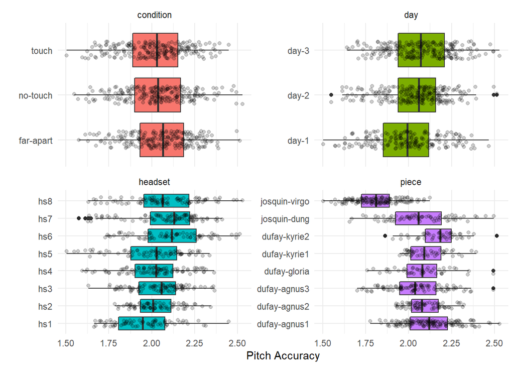

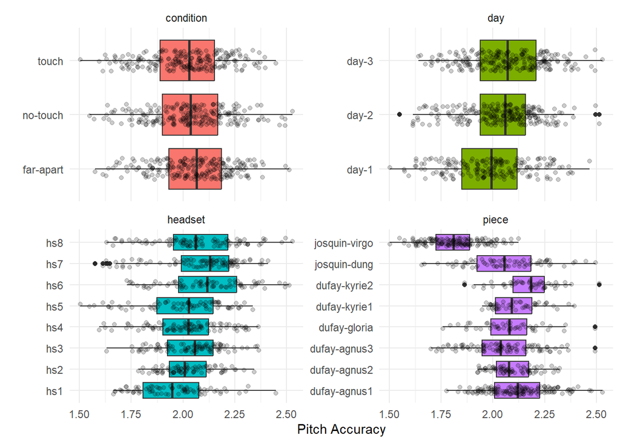

Figure 1a. Pitch accuracy for condition, day, piece and headset (singer)

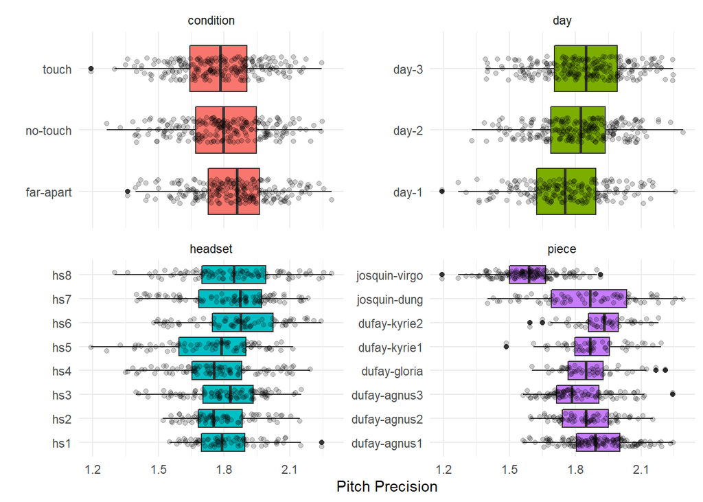

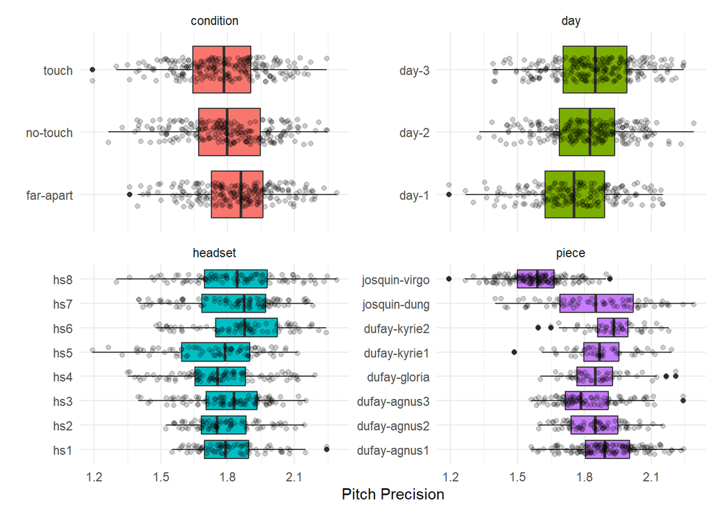

Table 2. Mixed linear regression models for pitch accuracy and pitch precisionn.

| Indicator | Term | beta | p |
| --- | --- | --- | --- |
| Pitch Accuracy | (Intercept) | 2.077 | 0.000*** |
|  | no-touch | -0.021 | 0.097. |
|  | touch | -0.039 | 0.002** |
| Pitch Precision | (Intercept) | 1.865 | 0.000*** |
|  | no-touch | -0.046 | 0.001*** |
|  | touch | -0.066 | 0.000*** |

The linear regression model for inner pitch accuracy and precision can be found in Tab. 3. Here we see only significant effects of inner pitch accuracy but not for inner pitch precision.

Table 3. Linear Regression models for inner pitch accuracy and pitch precision.

| Indicator | Term | beta | p |
| --- | --- | --- | --- |
| Pitch Accuracy | (Intercept) | 1.884 | 0.000*** |
|  | no-touch | -0.090 | 0.000*** |
|  | touch | -0.105 | 0.000*** |
| Pitch Precision | (Intercept) | 1.528 | 0.000*** |
|  | no-touch | -0.072 | 0.101 |
|  | touch | -0.067 | 0.128 |

Table 4. Approximate effect sizes global and inner pitch accuracy and pitch precision.

| Indicator | Contrast | Cohen's d | p |
| --- | --- | --- | --- |
| Pitch Accuracy | No Touch --. Far Apart | -0.124 | 0.290 |
|  | Touch --. Far Apart | -0.281 | 0.002** |
|  | Touch --. No touch | -0.157 | 0.137 |
| Pitch Precision | No Touch --. Far Apart | -0.358 | 0.000*** |
|  | Touch --. Far Apart | -0.500 | 0.000*** |
|  | Touch --. No touch | -0.142 | 0.184 |
| Within Pitch Accuracy | No Touch --. Far Apart | -0.670 | 0.000*** |
|  | Touch --. Far Apart | -0.824 | 0.000*** |
|  | Touch --. No touch | -0.154 | 0.322 |
| Within Pitch Precision | No Touch --. Far Apart | -0.519 | 0.000*** |
|  | Touch --. Far Apart | -0.583 | 0.000*** |
|  | Touch --. No touch | -0.065 | 0.833 |

### Pitch errors

For singing errors, as defined above, We calculated a mixed logistic regression with day, piece, and headset as random effects and condition as fixed effects. The results can be found in Table 5. Both the touch and the no-touch condition had a significant increase of error rates compared to the far-apart condition with a 55% and 59% increase of odd ratios.

Table 5. Mixed logistic regression models for singing errors.

| Term | beta | exp(beta) | p |
| --- | --- | --- | --- |
| (Intercept) | -5.688 | 0.003 | 0.000*** |
| no-touch | 0.441 | 1.554 | 0.001** |
| touch | 0.467 | 1.595 | 0.001*** |

Table 2. Mixed linear regression models for pitch accuracy and pitch precisionn.

| Indicator | Term | beta | p |
| --- | --- | --- | --- |
| Pitch Accuracy | (Intercept) | 2.076 | 0.000*** |
|  | no-touch | -0.020 | 0.117 |
|  | touch | -0.038 | 0.003** |
| Pitch Precision | (Intercept) | 1.863 | 0.000*** |
|  | no-touch | -0.045 | 0.001*** |
|  | touch | -0.064 | 0.000*** |

The linear regression model for inner pitch accuracy and precision can be found in Tab. 3. Here we see only significant effects of inner pitch accuracy but not for inner pitch precision.

Table 3. Linear Regression models for inner pitch accuracy and pitch precision.

| Indicator | Term | beta | p |
| --- | --- | --- | --- |
| Pitch Accuracy | (Intercept) | 1.877 | 0.000*** |
|  | no-touch | -0.084 | 0.000*** |
|  | touch | -0.100 | 0.000*** |
| Pitch Precision | (Intercept) | 1.521 | 0.000*** |
|  | no-touch | -0.065 | 0.136 |
|  | touch | -0.060 | 0.171 |

In order to get estimates for the relative effect sizes of intonation LMMs, we resorted to standardization of global and inner pitch accuracy and pitch precision by day, headset and piece and subsequently calculation of Tukey contrasts, which give then approximate effect sizes for the single contrast. Effects are generally of low to medium size, the largest can be found for touch vs. far-part conditions for inner pitch accuracy with `d = -.819`. Generally, the largest effect sizes can be found for this pair of conditions for all four performance indicators. However, the absolute effect sizes between conditions in terms of absolute pitch errors are less than 1 cent (average 0.4 cents, range -2.1 to 3.7 cents for touch vs. far-apart), which is way less than any pitch discrimnation threshold.

Table 4. Approximate effect sizes global and inner pitch accuracy and pitch precision.

| Indicator | Contrast | Cohen's d | p |
| --- | --- | --- | --- |
| Global Pitch Accuracy | no-touch-far-apart | -0.122 | 0.302 |
|  | touch-far-apart | -0.279 | 0.002** |
|  | touch-no-touch | -0.158 | 0.135 |
| Global Pitch Precision | no-touch-far-apart | -0.354 | 0.000*** |
|  | touch-far-apart | -0.495 | 0.000*** |
|  | touch-no-touch | -0.141 | 0.186 |
| Inner Pitch Accuracy | no-touch-far-apart | -0.654 | 0.000*** |
|  | touch-far-apart | -0.818 | 0.000*** |
|  | touch-no-touch | -0.164 | 0.280 |
| Inner Pitch Precision | no-touch-far-apart | -0.505 | 0.000*** |
|  | touch-far-apart | -0.575 | 0.000*** |
|  | touch-no-touch | -0.070 | 0.806 |

### Pitch errors

For singing errors, as defined above, We calculated a mixed logistic regression with day, piece, and headset as random effects and condition as fixed effects. The results can be found in Table 5. Both the touch and the no-touch condition had a significant increase of error rates compared to the far-apart condition with a 55% and 59% increase of odd ratios.

Table 5. Mixed logistic regression models for singing errors.

| Term | beta | exp(beta) | p |
| --- | --- | --- | --- |
| (Intercept) | -5.694 | 0.003 | 0.000*** |
| no-touch | 0.447 | 1.563 | 0.001** |
| touch | 0.472 | 1.604 | 0.001*** |

### Pitch drift

We used the slope of overall pitch drift per section as another performance indicator and subjected it to a mixed linear regression with condition as fixed effect and day and piece as random effect. The model did not show significant results for condition, though there was considerable variation in pitch drift with respect to sections, mostly showing downward drift (78.8 % of all cases). About of 24.6% the slopes were significantly different from 0 on the 5% level, indicating that pitch drift is a very common phenomenon.

Total drift across sections is, however, small with -9.7 cents on average and a range from -66.1 to 22.9 cents.

## Timing

The distribution of onset precision between voices for condition, day, and piece can be seen in Fig. 2a, and those for with voices in Fig. 2b. To check for main effects of condition, piece, day, and voice type (for inner onset precision) we again used permutation test (`coin::indepence_test`), which only showed effects for piece for mean onset precision and for piece and voice type for inner onset precision. However, the mixed linear regression models for both types of onset precision, using condition as fixed effect and day and piece and day, piece, and voice type, resp., did show one significant effect for the touch condition in the case of onset precision across voices. This is has a medium relative effect size of `d = -.662`, i.e., lower onset precision for *touch* compared to *far-apart* (again calculated using standardization across random effects and then using Tukey contrasts). However, the absolute effect size is only `d = -0.0035`, i.e., about 4 ms, way below any onset discrimination threshold.

Table 6. Mixed linear regression models for mean onset precision between voices.

| Indicator | Term | beta | p |
| --- | --- | --- | --- |
| Mean Onset Precision | (Intercept) | -3.072 | 0.000*** |
|  | no-touch | -0.008 | 0.463 |
|  | touch | -0.043 | 0.000*** |

Table 7. Mixed linear regression models for mean onset precision within voices.

| Indicator | Term | beta | p |
| --- | --- | --- | --- |
| Mean Onset Precision | (Intercept) | 2.805 | 0.000*** |
|  | no-touch | -0.021 | 0.245 |
|  | touch | -0.009 | 0.614 |

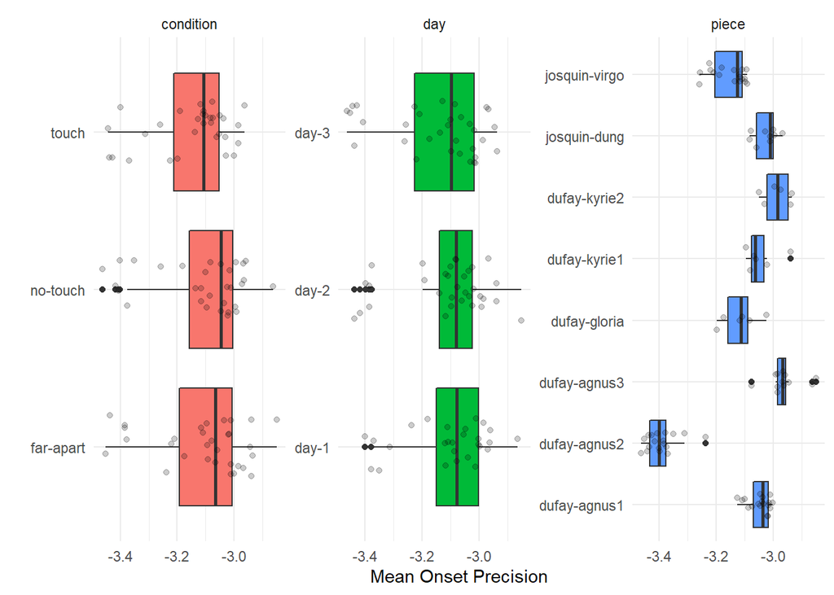

The distribution of onset precision between voices for condition, day, and piece can be seen in Fig. 2a, and those for with voices in Fig. 2b. To check for main effects of condition, piece, day, and voice type (for inner onset precision) we again used permutation test (`coin::indepence_test`), which only showed effects for piece for mean onset precision and for piece and voice type for inner onset precision. However, the mixed linear regression models for both types of onset precision, using condition as fixed effect and day and piece and day, piece, and voice type, resp., did show one significant effect for the touch condition in the case of onset precision across voices. This is has a medium relative effect size of `d = -.662`, i.e., lower onset precision for *touch* compared to *far-apart* (again calculated using standardization across random effects and then using Tukey contrasts). However, the absolute effect size is only `d = -0.0035`, i.e., about 4 ms, way below any onset discrimination threshold.

Table 6. Mixed linear regression models for mean onset precision between voices.

| Indicator | Term | beta | p |
| --- | --- | --- | --- |
| Mean Onset Precision | (Intercept) | -3.074 | 0.000*** |
|  | no-touch | -0.007 | 0.563 |
|  | touch | -0.041 | 0.001*** |

Table 7. Mixed linear regression models for mean onset precision within voices.

| Indicator | Term | beta | p |
| --- | --- | --- | --- |
| Mean Onset Precision | (Intercept) | 2.806 | 0.000*** |
|  | no-touch | -0.021 | 0.238 |
|  | touch | -0.010 | 0.600 |

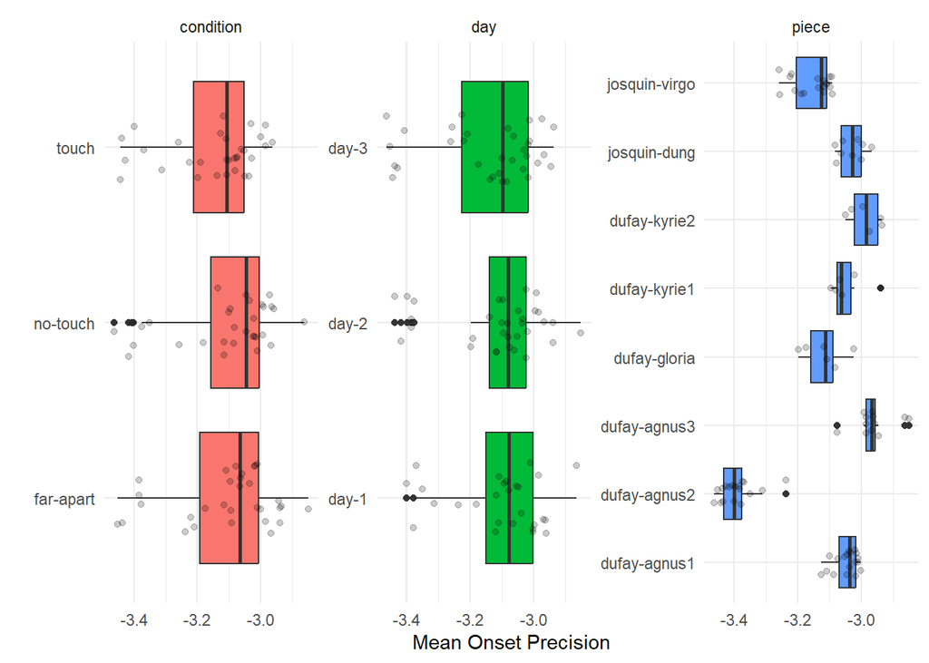

Figure 2a. Mean onset precision for condition, day, and piece

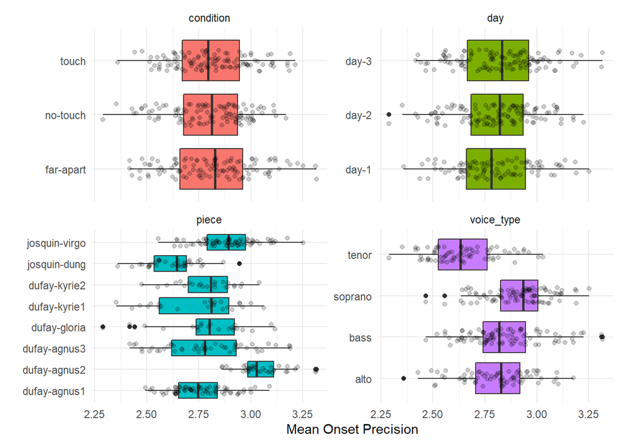

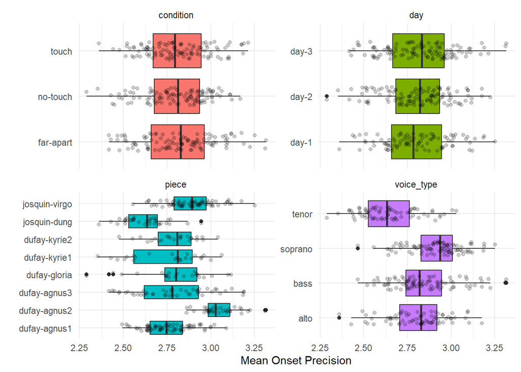

Figure 2b. Inner onset precision for condition, day, piece and voice type

## Timing Errors

Table 8. Mixed logistic regression models for timing error between voices.

| Term | beta | exp(beta) | p |
| --- | --- | --- | --- |
| (Intercept) | -3.211 | 0.040 | 0.000*** |
| no-touch | 0.121 | 1.128 | 0.309 |
| touch | -0.249 | 0.780 | 0.053. |

Within voice, timing errors were defined as onset differences greater than a fixed threshold of 300 ms (maximal quarter note duration) and used a logistic regression for so defined errors with condition as fixed effect and day, piece, and voice type as random effects. Results can be found in Table 9. Here, the no-touch condition became significant with a 116% increase in odd ratios

Table 9. Mixed logistic regression models for timing error within voices.

| Term | beta | exp(beta) | p |
| --- | --- | --- | --- |
| (Intercept) | -5.831 | 0.003 | 0.000*** |
| no-touch | 0.771 | 2.163 | 0.000*** |
| touch | -0.067 | 0.935 | 0.767 |

### Tempo and tempo drift

Table 10. Mixed linear regression models for tempo slope, tempo change, and mean tempo

| Indicator | Term | beta | p |
| --- | --- | --- | --- |
| Neg. logarithm of absolute tempo slope | (Intercept) | 8.345 | 0.000*** |
|  | no-touch | 0.080 | 0.434 |
|  | touch | 0.128 | 0.214 |
| Mean quarter length duration | (Intercept) | 0.202 | 0.000*** |
|  | no-touch | 0.000 | 0.920 |
|  | touch | -0.003 | 0.001*** |
| Neg. logarithm of absolute tempo change | (Intercept) | 3.823 | 0.000*** |
|  | no-touch | 0.070 | 0.499 |
|  | touch | 0.132 | 0.205 |

Table 8. Mixed logistic regression models for timing error between voices.

| Term | beta | exp(beta) | p |
| --- | --- | --- | --- |
| (Intercept) | -3.192 | 0.041 | 0.000*** |
| no-touch | 0.106 | 1.112 | 0.370 |
| touch | -0.264 | 0.768 | 0.040* |

Within voice, timing errors were defined as onset differences greater than a fixed threshold of 300 ms (maximal quarter note duration) and used a logistic regression for so defined errors with condition as fixed effect and day, piece, and voice type as random effects. Results can be found in Table 9. Here, the no-touch condition became significant with a 116% increase in odd ratios

Table 9. Mixed logistic regression models for timing error within voices.

| Term | beta | exp(beta) | p |
| --- | --- | --- | --- |
| (Intercept) | -5.825 | 0.003 | 0.000*** |
| no-touch | 0.767 | 2.153 | 0.000*** |
| touch | -0.071 | 0.931 | 0.752 |

### Tempo and tempo drift

Table 10. Mixed linear regression models for tempo slope, tempo change, and mean tempo

| Indicator | Term | beta | p |
| --- | --- | --- | --- |
| Neg. logarithm of absolute tempo slope | (Intercept) | 8.342 | 0.000*** |
|  | no-touch | 0.082 | 0.421 |
|  | touch | 0.130 | 0.206 |
| Mean quarter length duration | (Intercept) | 0.202 | 0.000*** |
|  | no-touch | 0.000 | 0.984 |
|  | touch | -0.003 | 0.001*** |
| Neg. logarithm of absolute tempo change | (Intercept) | 3.820 | 0.000*** |
|  | no-touch | 0.072 | 0.486 |
|  | touch | 0.134 | 0.198 |

# Discussion

Compared to monastic choirs in the medieval times, where touching during might be very common, if not the standard setup for singing or at least singing teaching. In this regard, the performance of this modern professional choir cna hardly be fairly compared with medieval monks.

However, it has to be noted that the effect size are basically minuscule, particularly, when measured in absolute terms. The relative effects are low to medium but this is mainly an indicator of the general high precision of the choir. Generally, all performance differences might be well below perceptual thresholds and hence probably unnoticeable by the audience. One could, however, conjecture that the close and touch conditions could have more detrimental effects on less professional choirs.

# Appendix

Table A!. Overview of analytical units.

| Element | Number |
| --- | --- |
| Works | 4 |
| Parts | 8 |
| Takes | 24 |
| Sections/Audio Tracks | 93 |
| Singers/Headsets | 8 |
| Note Tracks | 672 |
| Voice Types | 4 |
| Conditions | 3 |
| Recording days | 3 |
| All tone events (all) | 65,280 |
| Tone events (excluding pitch errors) | 64,215 |

Table A2. Basic statistics of the single takes.

| Take | Condition | Piece | Repetition | No. Notes | No. Voices |
| --- | --- | --- | --- | --- | --- |
| take05 | touch | dufay-agnus1 | 1 | 609 | 4 |
|  |  | dufay-agnus2 | 1 | 429 | 2 |
|  |  | dufay-agnus3 | 1 | 601 | 4 |
|  |  | dufay-agnus1 | 2 | 617 | 4 |
|  |  | dufay-agnus2 | 2 | 429 | 2 |
|  |  | dufay-agnus3 | 2 | 606 | 4 |
| take06 | no-touch | dufay-agnus1 | 1 | 624 | 4 |
|  |  | dufay-agnus2 | 1 | 430 | 2 |
|  |  | dufay-agnus3 | 1 | 608 | 4 |
|  |  | dufay-agnus1 | 2 | 612 | 4 |
|  |  | dufay-agnus2 | 2 | 427 | 2 |
|  |  | dufay-agnus3 | 2 | 606 | 4 |
| take07 | far-apart | dufay-agnus1 | 1 | 618 | 4 |
|  |  | dufay-agnus2 | 1 | 434 | 2 |
|  |  | dufay-agnus3 | 1 | 613 | 4 |
|  |  | dufay-agnus1 | 2 | 610 | 4 |
|  |  | dufay-agnus2 | 2 | 427 | 2 |
|  |  | dufay-agnus3 | 2 | 614 | 4 |
| take08 | touch | josquin-dung | 1 | 479 | 4 |
|  |  | josquin-virgo | 1 | 1,003 | 4 |
|  |  | josquin-virgo | 2 | 889 | 4 |
| take09 | no-touch | josquin-dung | 1 | 491 | 4 |
|  |  | josquin-virgo | 1 | 1,033 | 4 |
|  |  | josquin-virgo | 2 | 1,001 | 4 |
| take10 | far-apart | josquin-dung | 1 | 505 | 4 |
|  |  | josquin-virgo | 1 | 950 | 4 |
|  |  | josquin-virgo | 2 | 1,047 | 4 |
| take15 | no-touch | josquin-dung | 1 | 505 | 4 |
|  |  | josquin-virgo | 1 | 1,044 | 4 |
|  |  | josquin-virgo | 2 | 1,038 | 4 |

[output cut: 63 more lines]

Tab. A3. Independence (Permutation) tests for pitch performance indicators.

| Type | Indicator | Variable | Statistic | p |
| --- | --- | --- | --- | --- |
| Single voices | Mean Pitch Accurary | condition | 1.97 | 0.121 |
|  |  | day | 4.02 | 0.000*** |
|  |  | headset | 4.25 | 0.000*** |
|  |  | piece | 16.10 | 0.000*** |
|  | Mean Pitch Precision | condition | 3.57 | 0.001*** |
|  |  | day | 4.20 | 0.000*** |
|  |  | headset | 3.01 | 0.020* |
|  |  | piece | 15.83 | 0.000*** |
| Within voices | Mean Pitch Accurary | condition | 3.87 | 0.000*** |
|  |  | day | 2.89 | 0.011* |
|  |  | voice_type | 5.11 | 0.000*** |
|  |  | piece | 8.61 | 0.000*** |
|  | Mean Pitch Precision | condition | 1.37 | 0.354 |
|  |  | day | 0.47 | 0.886 |
|  |  | voice_type | 6.38 | 0.000*** |
|  |  | piece | 6.84 | 0.000*** |

Tab. A4. Independence (Permutation) tests for onset performance indicators.

| Type | Indicator | Variable | Statistic | p |
| --- | --- | --- | --- | --- |
| Between voices | Mean Onset Precision | condition | 1.13 | 0.497 |
|  |  | day | 1.04 | 0.553 |
|  |  | piece | 8.26 | 0.000*** |
| Within voices |  | condition | 0.74 | 0.738 |
|  |  | day | 1.03 | 0.559 |
|  |  | voice_type | 8.58 | 0.000*** |
|  |  | piece | 8.07 | 0.000*** |

Table A1. Basic statistics of the single takes.

| Take | Condition | Piece | Repetition | No. Notes | No. Voices |
| --- | --- | --- | --- | --- | --- |
| take05 | touch | dufay-agnus1 | 1 | 609 | 4 |
|  |  | dufay-agnus2 | 1 | 429 | 2 |
|  |  | dufay-agnus3 | 1 | 601 | 4 |
|  |  | dufay-agnus1 | 2 | 617 | 4 |
|  |  | dufay-agnus2 | 2 | 429 | 2 |
|  |  | dufay-agnus3 | 2 | 606 | 4 |
| take06 | no-touch | dufay-agnus1 | 1 | 624 | 4 |
|  |  | dufay-agnus2 | 1 | 430 | 2 |
|  |  | dufay-agnus3 | 1 | 608 | 4 |
|  |  | dufay-agnus1 | 2 | 612 | 4 |
|  |  | dufay-agnus2 | 2 | 427 | 2 |
|  |  | dufay-agnus3 | 2 | 606 | 4 |
| take07 | far-apart | dufay-agnus1 | 1 | 618 | 4 |
|  |  | dufay-agnus2 | 1 | 434 | 2 |
|  |  | dufay-agnus3 | 1 | 613 | 4 |
|  |  | dufay-agnus1 | 2 | 610 | 4 |
|  |  | dufay-agnus2 | 2 | 427 | 2 |
|  |  | dufay-agnus3 | 2 | 614 | 4 |
| take08 | touch | josquin-dung | 1 | 479 | 4 |
|  |  | josquin-virgo | 1 | 1,003 | 4 |
|  |  | josquin-virgo | 2 | 889 | 4 |
| take09 | no-touch | josquin-dung | 1 | 491 | 4 |
|  |  | josquin-virgo | 1 | 1,033 | 4 |
|  |  | josquin-virgo | 2 | 1,001 | 4 |
| take10 | far-apart | josquin-dung | 1 | 443 | 4 |
|  |  | josquin-virgo | 1 | 950 | 4 |
|  |  | josquin-virgo | 2 | 1,047 | 4 |
| take15 | no-touch | josquin-dung | 1 | 505 | 4 |
|  |  | josquin-virgo | 1 | 1,044 | 4 |
|  |  | josquin-virgo | 2 | 1,038 | 4 |

[output cut: 63 more lines]